[figure not shown]

MBA EM JORNALISMO DE DADOS  
Introdução à linguagem Python  
Rodolfo Viana

# AULA 4 — COLEÇÕES DE DADOS E *FOR LOOP*

Nesta aula veremos:

1. Coleções de dados
1. Lista
2. Tupla
3. Conjunto
2. *For loop*

# Coleções de dados

Em aulas anteriores vimos os tipos primitivos de dados, como:

→ *integer* (`int`): `4`, `-12`, `6745`...

→ *float* (`float`): `4.67`, `-12.01973`, `6745.0`...

→ *bool* (`bool`): `True`, `False`

→ *string* (`str`): `"Python"`, `"maçã"`, `"Rodolfo"`, `"6.0"`...

Também vimos como armazenar dados na memória com o uso de variáveis. Por exemplo:

```
idade = 42
nome = "Rodolfo"
print("{} tem {} anos.".format(nome, idade))
```

Muitas vezes, porém, precisamos armazenar mais de um valor numa variável. Por exemplo, as contas do mês:

```
# Como eu posso colocar todas as contas distintas numa variável única?
aluguel = 1400
luz = 110
agua = 90
internet = 100
gas = 25
cartao = 800
```

Para armazenamos múltiplos dados numa variável, há as coleções de dados do Python. Há quatro coleções muito comuns, cada uma com características e funções próprias. Veremos três delas nesta aula.

### Lista

A primeira coleção é a **lista** (classe `list`), feita com valores dentro de colchetes (`[` e `]`) ou simplesmente chamando a função `list()`.

```python
aluguel = 1400
luz = 110
agua = 90
internet = 100
gas = 25
cartao = 800

contas = [aluguel, luz, agua, internet, gas, cartao] # Aqui eu crio uma lista

print(contas)
print(type(contas))
```

```
[1400, 110, 90, 100, 25, 800]
<class 'list'>
```

```python
linguagens = ["Python", "SQL", "Javascript", "C++"]
print(linguagens)
print(type(linguagens))
```

```
['Python', 'SQL', 'Javascript', 'C++']
<class 'list'>
```

Posso também misturar tipos de dados dentro de uma lista...

```python
mix = [12, "Cenoura", 3.72, True]
print(mix)
```

```
[12, 'Cenoura', 3.72, True]
```

...fazer lista de listas...

```python
lista1 = [1, 2, 3]
lista2 = [4, 5, 6]
listona = [lista1, lista2]
print(listona)
```

```
[[1, 2, 3], [4, 5, 6]]
```

...e juntar várias listas numa só.

```python
listona2 = lista1 + lista2
print(listona2)
```

```
[1, 2, 3, 4, 5, 6]
```

Para acessar cada elemento da lista, é preciso usar a posição do elemento dentro de colchetes (`[` e `]`). Mas lembre-se: **Python começa a contagem no índice 0** (ou seja, o primeiro elemento é 0, o segundo é 1, o terceiro é 2...).

```python
linguagens = ["Python", "SQL", "Javascript", "C++", "Java", "HTML"]
# índice         0        1          2         3       4      5

print("A linguagem na terceira posição é {}".format(linguagens[2]))
print("A linguagem na quarta posição é {}".format(linguagens[3]))
print("A linguagem na primeira posição é {}".format(linguagens[0]))
```

```
A linguagem na terceira posição é Javascript
A linguagem na quarta posição é C++
A linguagem na primeira posição é Python
```

A indexação permite, inclusive, realizar cálculos.

```python
lista = [3.14, 2.09, 8.21, -7,55]

print(lista[1] * lista[3])
```

```
-14.629999999999999
```

É possível acessar múltiplos elementos passando o índice de começo e de fim (mas preste atenção: **o resultado exclui o último item**). Funciona assim: `[onde começa:onde termina + 1]`

```python
linguagens = ["Python", "SQL", "Javascript", "C++", "Java", "HTML"]
# índice         0        1          2         3       4      5

print(linguagens[2:5]) # começa no índice 2 e termina no índice 4 (por isso usei 5, pois 4 + 1)
```

```
['Javascript', 'C++', 'Java']
```

"E como funciona essa indexação quanto temos uma lista de listas?" Vamos ver com um exemplo:

```
exemplo = [["vermelho", "amarelo", "azul"], ["verde", "roxo", "preto"]]
```

Neste caso, temos duas listas dentro de uma lista. O desenho é assim:

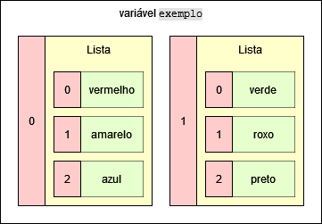

A variável `exemplo` tem dois elementos. Cada elemento é uma lista. Então, se eu chamar isso...

```
exemplo[1] # o segundo item da variável `exemplo`
```

...terei como retorno isso:

```
["verde", "roxo", "preto"] # uma lista
```

Se eu quero acessar `preto`, preciso então indicar o índice dentro da lista que acesso com `exemplo[1]`. Fica assim:

```
exemplo[1][2] # do segundo item, quero o terceiro item, ou seja, "preto"
```

Ou seja, o terceiro item dentro da segunda lista da variável `exemplo`.

Vamos ver na prática:

```python
exemplo = [["vermelho", "amarelo", "azul"], ["verde", "roxo", "preto"]]
print(exemplo[1])
print(exemplo[1][2])
```

```
['verde', 'roxo', 'preto']
preto
```

Como na aula passada vimos `if-elif-else`, vale a gente ver o uso de controle de fluxo com listas e apresentar dois operadores — e, para o exemplo abaixo, consideramos `nomes = ["João", "André", "Ana", "Maria"]`:

| operador | significado | exemplo | resultado |
| --- | --- | --- | --- |
| `in` | está contido em | `"João" in nomes` | `True` |
| `not in` | não está contido em | `"Pedro" not in nomes` | `True` |

```python
nomes = ["João", "André", "Ana", "Maria"]

print('Ana' not in nomes)
print('Maria' in nomes)
```

```
False
True
```

```python
nome = "Claudio"
lista_nomes = ["Renato", "Ana", "Fernanda"]

if nome not in lista_nomes: # "Se o nome não estiver na lista..."
    print("O nome {} não está na lista.".format(nome))
else:
    print("O nome {} está na lista.".format(nome))
```

```
O nome Claudio não está na lista.
```

As listas são **mutáveis**: posso adicionar e excluir elementos, mostrar em ordem reversa etc. com algumas funções:

→ `.append(x)` para adicionar um elemento `x`

→ `.pop(i)` para tirar da lista um elemento de índice `i` e mostrar esse elemento

→ `.remove(x)` para tirar um elemento `x`

→ `.reverse()` para inverter a ordem dos elementos

→ `.sort()` para organizar os elementos do menor ao maior (ou do maior ao menor, se usar `reverse=True`)

→ `.count(x)` para contar quantas vezes o elemento `x` aparece na lista

```python
lista = ["Carlos", "Antonio", "Cesar"]
print(lista)

lista.append("Rodolfo") # adicionar "Rodolfo"
print(lista)

lista.remove("Cesar") # remover "Cesar"
print(lista)

lista.reverse() # colocar em ordem reversa
print(lista)

lista.sort(reverse=True) # ordenar do maior para o menor
print(lista)

print(lista.count("Rodolfo")) # contar quantas vezes aparece "Rodolfo"
```

```
['Carlos', 'Antonio', 'Cesar']
['Carlos', 'Antonio', 'Cesar', 'Rodolfo']
['Carlos', 'Antonio', 'Rodolfo']
['Rodolfo', 'Antonio', 'Carlos']
['Rodolfo', 'Carlos', 'Antonio']
1
```

### Tupla

A segunda é a **tupla** (classe `tuple`), feita com valores dentro de parênteses (`(` e `)`) ou com a função `tuple()`.

```python
valores = (1, 2, 99)
print(valores)
print(type(valores))
```

```
(1, 2, 99)
<class 'tuple'>
```

Assim como listas, tuplas podem conter dados de tipos variados, e é possível criar uma tupla de tuplas (ou de listas). Também a forma de localizar elementos por meio da indexação é similar.

```python
tupla_1 = (4, False, "maçã", 8.91) # tupla com diversos tipos
print(tupla_1)

tupla_2 = ((1, 2, 3), (9, 8, 7)) # tupla contendo duas tuplas
print(tupla_2)

tupla_3 = (("Ana", "Pedro", "Claudio"), ("José", "Maria", "João"))
print(tupla_3[0][2]) # indexação para encontrar "Claudio"
```

```
(4, False, 'maçã', 8.91)
((1, 2, 3), (9, 8, 7))
Claudio
```

Entretanto, as semelhanças acabam aí. Ao contrário de listas, **tuplas são imutáveis**. Ou seja, elementos não podem ser removidos, adicionados, reordenados etc.

```python
vegetais = ("acelga", "repolho", "alface")
print(vegetais)
```

```
('acelga', 'repolho', 'alface')
```

```python
vegetais.remove("acelga")
```

```
---------------------------------------------------------------------------
AttributeError                            Traceback (most recent call last)
Cell In[16], line 1
----> 1 vegetais.remove("acelga")

AttributeError: 'tuple' object has no attribute 'remove'
```

```python
vegetais.append("rúcula")
```

```
---------------------------------------------------------------------------
AttributeError                            Traceback (most recent call last)
Cell In[17], line 1
----> 1 vegetais.append("rúcula")

AttributeError: 'tuple' object has no attribute 'append'
```

Daí a importância de tuplas: **elas são úteis quando precisamos nos certificar de que os elementos não foram ou não serão alterados**. É comum, inclusive, converter listas em tuplas para que seus dados não sejam modificados.

```python
cores = ["amarelo", "verde", "azul", "vermelho"]
print("Temos {}, o que permite que eu altere seus elementos: {}".format(type(cores), cores))

cores = tuple(cores) # converto a lista para tupla
print("Agora temos {}, impossibilitando alterações: {}".format(type(cores), cores))
```

```
Temos <class 'list'>, o que permite que eu altere seus elementos: ['amarelo', 'verde', 'azul', 'vermelho']
Agora temos <class 'tuple'>, impossibilitando alterações: ('amarelo', 'verde', 'azul', 'vermelho')
```

### Conjunto

A terceira é o **conjunto** (classe `set`), feita com valores dentro de chaves (`{` e `}`) ou com a função `set()`.

```python
conjunto = {1, 2, 3, 4, 5}
print(conjunto)
print(type(conjunto))
```

```
{1, 2, 3, 4, 5}
<class 'set'>
```

As diferenças mais significativas entre conjuntos e as coleções anteriores são que, ao contrário de listas e tuplas,

1. **conjuntos não retornam repetições**.

```python
valores = [1, 1, 1, 2, 2, 3, 4, 4, 5, 5, 5] # lista
print(valores)

valores = tuple(valores) # tupla
print(valores)

valores = set(valores) # conjunto
print(valores)
```

```
[1, 1, 1, 2, 2, 3, 4, 4, 5, 5, 5]
(1, 1, 1, 2, 2, 3, 4, 4, 5, 5, 5)
{1, 2, 3, 4, 5}
```

2. **conjuntos não permitem indexação**.

```python
print(valores[1])
```

```
---------------------------------------------------------------------------
TypeError                                 Traceback (most recent call last)
Cell In[21], line 1
----> 1 print(valores[1])

TypeError: 'set' object is not subscriptable
```

Com essas peculiaridades, é comum haver conversões de listas para conjuntos e, de novo, para listas: imagine que temos uma lista com 30 valores, e queremos

1. reordená-los do maior para o menor, excluindo valores duplicados, e
2. encontrar os valores que estão nas posições 3 a 5.

Sabemos que exclusão de duplicatas pode ser feita com conjuntos, e não com listas; sabemos que reordenação e indexação podem ser executadas com listas, e não com conjuntos. Então...

```python
nums = [
    7, 1, 5, 3, 3, 4, 9, 5, 3, 1,
    8, 9, 1, 1, 8, 5, 5, 7, 2, 6,
    5, 4, 7, 1, 6, 3, 2, 3, 1, 9,
]
print(nums)

nums = set(nums) # com conjunto, excluo duplicatas...
print(nums)

nums = list(nums) # ...aí converto de volta para lista...
print(nums)

nums.sort(reverse=True) # ...e, na lista, reordeno do maior para o menor...
print(nums)

print(nums[3:6]) # ...para buscar valores por indexação
```

```
[7, 1, 5, 3, 3, 4, 9, 5, 3, 1, 8, 9, 1, 1, 8, 5, 5, 7, 2, 6, 5, 4, 7, 1, 6, 3, 2, 3, 1, 9]
{1, 2, 3, 4, 5, 6, 7, 8, 9}
[1, 2, 3, 4, 5, 6, 7, 8, 9]
[9, 8, 7, 6, 5, 4, 3, 2, 1]
[6, 5, 4]
```

# *For loop*

Agora que vimos três coleções de dados (`list`, `tuple` e `set`), podemos imaginar:

> E se o programador quiser realizar a mesma operação para cada item da coleção? Deve escrever tudo de novo?

A resposta é: não. **Podemos usar controle de fluxo com *for*** (ou `for loop`, como é conhecido).

O `for-loop` itera (ou seja, repete) a operação ou o comando para cada item da coleção. Sua sintaxe é assim:

```
for elemento in colecao:
    operacao
```

Seria como dizer em português: "para cada elemento da coleção, faça determinada operação". Em desenho,

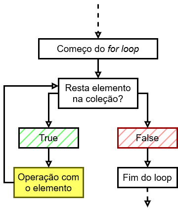

Por exemplo, quero aumentar os preços da minha loja em 15%:

```python
precos_atuais = [8.77, 9.12, 10.09, 6.71] # lista de preços atuais
precos_novos = list() # lista vazia que conterá os preços novos
percentual_aumento = 0.15 # percentual de aumento

for i in precos_atuais: # para cada item (apelidado de i) na lista `precos_atuais`...
    novo_valor = round(i + (i * percentual_aumento), 2) # ...calculo o novo valor...
    precos_novos.append(novo_valor) # ...e adiciono o novo valor na lista `precos_novos`

print(precos_novos)
```

```
[10.09, 10.49, 11.6, 7.72]
```

É possível ordenar ao sistema que realize qualquer operação, como passar uma lista de nomes, pedir as primeiras duas letras de cada nome e converter para letra minúscula com `lower()`...

```python
nomes = ["José", "Manuel", "Carlos"]

for x in nomes:
    primeiras_letras = x[0:2]
    print(primeiras_letras.lower())
```

```
jo
ma
ca
```

...ou pedir ao usuário 3 números, salvá-los numa lista e pedir ao sistema que, para cada número, imprima se é par ou ímpar.

```python
lista_nums = list()

while len(lista_nums) < 3:
    num = int(input("Digite um número inteiro: "))
    lista_nums.append(num)

for x in lista_nums:
    if x % 2 == 0:
        print("É par")
    else:
        print("É ímpar")
```

```
Digite um número inteiro: 786
Digite um número inteiro: 955
Digite um número inteiro: 1205
É par
É ímpar
É ímpar
```

Nos exemplos acima, o `x` aparece duas vezes:

No primeiro:

```
for x in nomes:
```

No segundo:

```
for x in lista_nums:
```

**Afinal, o que é esse `x`?**

É, digamos, uma "variável temporária". É o nome que damos para o item da coleção que está sendo processado no momento — ou seja, as operações serão feitas em cima da "variável temporária". Quando o item termina de ser processado, a "variável temporária" é atribuída ao próximo item da coleção, e assim sucessivamente.

E não precisa ser `x`! Pode ser qualquer letra, nome etc. Vamos ver um exemplo:

```python
lista_exemplo = ["André", "Regina", "Fernanda", "Pedro"]
contador = 0

# eu uso `nome` como variável temporária para o item...
for nome in lista_exemplo:
    contador = contador + 1
    # ...e faço operação com essa variável temporária
    print("No {}º loop, a 'variável temporária' `nome` é {}".format(contador, nome))
```

```
No 1º loop, a 'variável temporária' `nome` é André
No 2º loop, a 'variável temporária' `nome` é Regina
No 3º loop, a 'variável temporária' `nome` é Fernanda
No 4º loop, a 'variável temporária' `nome` é Pedro
```

**Mais sobre os tópicos da aula**

Observação: os conteúdos abaixo também têm informações sobre a coleção *dicionários*. Veremos dicionários na próxima aula.

- Vídeos
  - [Loop for](https://www.youtube.com/watch?v=55rOjj6kEck), em Bóson Treinamentos
  - [Percorrendo listas, tuplas, dicionários e conjuntos](https://www.youtube.com/watch?v=W3juvRbfSk8), em Marcos Castro
  - [Quando usar Listas, Tuplas, Conjuntos e Dicionários em Python?](https://www.youtube.com/watch?v=6H0sup1qSsY), em Universo Discreto
- Leituras
  - [Coleções no Python: Listas, Tuplas e Dicionários](https://www.devmedia.com.br/colecoes-no-python-listas-tuplas-e-dicionarios/40678), em DevMedia
  - [Principais Estruturas de Dados no Python](https://www.treinaweb.com.br/blog/principais-estruturas-de-dados-no-python/), em TreinaWeb

**Atividade 1**

Na apostila referente à primeira aula, há um exemplo em que foi calculada a área de um círculo de 12,5 metros de raio. Vimos ali que a fórmula para isso é $A = \pi r^2$.

Retome esta fórmula para retornar os valores calculados para cada raio da lista 12,7, 29,1, 10,5 e 14,3.

**Atividade 2**

Na aula retrasada, fizemos uma atividade em sala que pedia ao usuário a informação de temperatura e retornava uma descrição mais ou menos assim:

- Menos que 0° é congelante,
- De 0º a 10° é muito frio,
- Acima de 10° a 17° é friozinho,
- Acima de 17° a 24° é ameno,
- Acima de 24° a 30° é calor,
- Acima de 30° é muito calor.

Esta atividade é parecida, mas em vez de uma temperatura qualquer, peça ao usuário as temperaturas de São Paulo, Rio de Janeiro, Belo Horizonte, Brasília e Recife. Adicione cada temperatura numa lista e, ao fim, retorne uma frase com a descrição de cada temperatura.

*Dica*: para saber a qual capital pertence cada temperatura, use a posição do valor na lista, o índice.